# JaB: Detecting Influential Nodes in TrumpWorld Network

## Intro

We replicate the TrumpWorld results presented in *Jackknife-after-Bootstrap: Detecting Influential Actors in a Network*.

The orignal TrumpWorld data from Buzzfeed News can be found [here](https://www.buzzfeednews.com/article/johntemplon/help-us-map-trumpworld).

#### Make Trump igraph

We first upload the data and convert it to an igraph object.

```r
## Import data set
trump_data <- read_excel("data/TrumpWorldData.xlsx")
trump_data <- as.data.frame(trump_data)

## Make it an igraph
trump_edgelist <- as.matrix(trump_data[ , c(2,4)])
trump_igraph <- graph_from_edgelist(trump_edgelist, directed = F )
```

#### LSMI Optimal seed-wave combo

Then calculate the LSMI optimal seed-wave combination under degree centrality. We will use the selected parameters for all three centrality statistics later in the report.

```r
set.seed(12)

### LSMI Cross Validation for optimal s-w combo
#make network object for snowboot package
trump_network <- igraph_to_network(trump_igraph)

#get optimal combination
trump_cv <- lsmi_cv(trump_network,
                    n.seeds = 1:20,
                    n.wave = 5)
trump_cv$best_combination
```

```
## n.seed n.wave
##     19      3
```

Note, this cross validation method seems to be very unstable, even with a set seed. This needs to be further explored. Our paper uses 14 seeds and 2 waves, so this is the parameter combination we will use moving forward.

## Do JaB Algorithm

In this section, we run the JaB algorithm with degree, closeness, and eigenvector centrality using the `JaB` function.

#### Set Parameters

We first set the initial parameters used with all three statistics.

```r
B=100
U=100
num_seed=14
num_wave=2
quants = c(0, 0.95)
mult = FALSE
print_null_dist = T
```

#### Degree Centrality

```r
### Do JaB degree
startTime <- Sys.time()
JaB_trump_degree <- JaB(trump_igraph,
                          B, U,
                          num_seed,
                          num_wave,
                          centrality_stat ="degree",
                          quants,
                          mult,
                          print_null_dist)
endTime <- Sys.time()

time_degree = endTime - startTime #~10 minutes
```

#### Closeness Centrality

```r
### Do JaB closeness
startTime <- Sys.time()
JaB_trump_closeness <- JaB(trump_igraph,
                          B , U,
                          num_seed,
                          num_wave,
                          centrality_stat ="closeness",
                          quants,
                          mult,
                          print_null_dist)
endTime <- Sys.time()

time_close = endTime - startTime #~12 minutes
```

#### Eigen Vector Centrality

```r
### Do JaB eigenvector
startTime <- Sys.time()
JaB_trump_eigen <- JaB(trump_igraph,
                       B , U,
                       num_seed,
                       num_wave,
                       centrality_stat ="eigen",
                       quants,
                       mult,
                       print_null_dist)
endTime <- Sys.time()

time_eigen = endTime - startTime #~10 minutes
```

## Look at Results

We now inspect our results and recreate certain figures and tables presented in the paper.

#### All Nodes

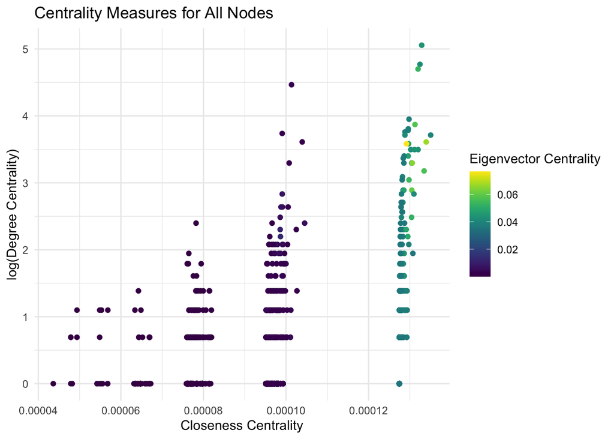

```r
## Make a table of all Results
all_results <- rbind( cbind(JaB_trump_degree$Results, stat = "degree"),
                  cbind(JaB_trump_closeness$Results, stat = "close"),
                  cbind(JaB_trump_eigen$Results, stat = "eigen")) %>%
    filter(Node_Name != "DONALD J. TRUMP")


#plot relationship among all three statistics
all_results %>%
  select(Node_Name, Orig_Stat, stat) %>%
  pivot_wider(names_from = stat, values_from = Orig_Stat)  %>%
  ggplot(aes(color = (eigen), x = close, y = log(degree))) +
  geom_point() +
  theme_minimal() +
  scale_color_viridis(name = "Eigenvector Centrality") +
  xlab("Closeness Centrality") +
  ylab("log(Degree Centrality)") +
  ggtitle("Centrality Measures for All Nodes")
```

```r
# correlations
all_results %>%
  select(Node_Name, rank, stat) %>%
  pivot_wider(names_from = stat, values_from = rank)  %>%
  select(-Node_Name) %>%
  cor()
```

```
##           degree     close    eigen
## degree 1.0000000 0.4333613 0.498058
## close  0.4333613 1.0000000 0.949395
## eigen  0.4980580 0.9493950 1.000000
```

#### Union set

Figure 5 and Table 2:

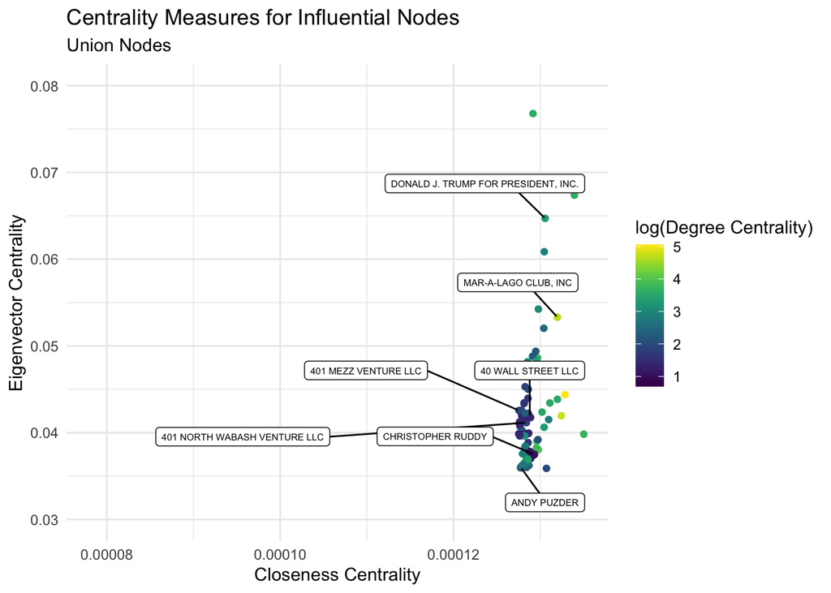

```r
## Get nodes in Union and Intersection set
influence_pivot <-
  all_results %>%
  select(Node_Name, stat, Influential) %>%
  pivot_wider(names_from = stat, values_from = Influential) %>%
  mutate(and = degree & close & eigen ) %>%
  mutate(or = degree | close | eigen)

union_names <- na.omit(influence_pivot$Node_Name[influence_pivot$or])
intersect_names <- na.omit(influence_pivot$Node_Name[influence_pivot$and])

## union results
union_results <-
  all_results %>%
  filter(Node_Name %in% union_names) %>%
  select(Node_Name, stat, Orig_Stat) %>%
  pivot_wider(names_from = stat, values_from = Orig_Stat) %>%
  arrange(Node_Name)

cool.names <- union_results$Node_Name[c(1,2,3, 12,  6, 48, 52, 7, 19 )]


#plot results
union_results %>%
  mutate(name = ifelse(Node_Name %in% cool.names, Node_Name, NA)) %>%
  ggplot(aes(color = log(degree), x = close, y = eigen)) +
  geom_point() +
  theme_minimal() +
  scale_color_viridis(name = "log(Degree Centrality)") +
  ylim(c(0.03, 0.08))+
  geom_label_repel( aes(label = name),
                    size = 2,
                    box.padding = 1,
                    min.segment.length  =0,
                    color = "black",
                    force = 10) +
  xlab("Closeness Centrality") +
  ylab("Eigenvector Centrality") +
  ggtitle("Centrality Measures for Influential Nodes")+
  labs(subtitle = "Union Nodes")
```

```r
#union results
union_results  %>%
  select(-Node_Name) %>%
  cor()
```

```
##            degree      close      eigen
## degree 1.00000000 0.01483366 0.03906856
## close  0.01483366 1.00000000 0.88127453
## eigen  0.03906856 0.88127453 1.00000000
```

#### Intersection results

The results from the intersection results are not included in the paper. They are presented here:

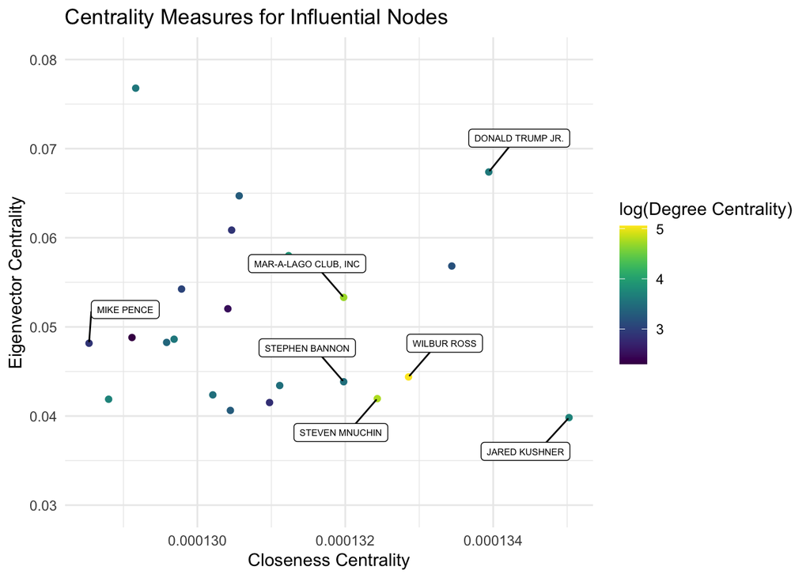

```r
intersect_results <-
  all_results %>%
  filter(Node_Name %in% intersect_names) %>%
  select(Node_Name, stat, Orig_Stat) %>%
  pivot_wider(names_from = stat, values_from = Orig_Stat) %>%
  arrange(Node_Name)

cool.names <- intersect_names[c(1,2,3, 12,  6, 48, 52, 7, 19 )]


#plot results
intersect_results %>%
  mutate(name = ifelse(Node_Name %in% cool.names, Node_Name, NA)) %>%
  ggplot(aes(color = log(degree), x = close, y = eigen)) +
  geom_point() +
  theme_minimal() +
  scale_color_viridis(name = "log(Degree Centrality)") +
  ylim(c(0.03, 0.08))+
  geom_label_repel( aes(label = name),
                    size = 2,
                    box.padding = 1,
                    min.segment.length  =0,
                    color = "black",
                    force = 10) +
  xlab("Closeness Centrality") +
  ylab("Eigenvector Centrality") +
  ggtitle("Centrality Measures for Influential Nodes")
```

```r
#union results
intersect_results  %>%
  select(-Node_Name) %>%
  cor()
```

```
##            degree       close       eigen
## degree  1.0000000  0.40905147 -0.17110047
## close   0.4090515  1.00000000 -0.06647486
## eigen  -0.1711005 -0.06647486  1.00000000
```

## Look at results for Paul Manafort

We now recreate Figure 6, and consider Paul Manafort’s influence under degree, closeness, and eigenvector centrality.

#### Degree centrality

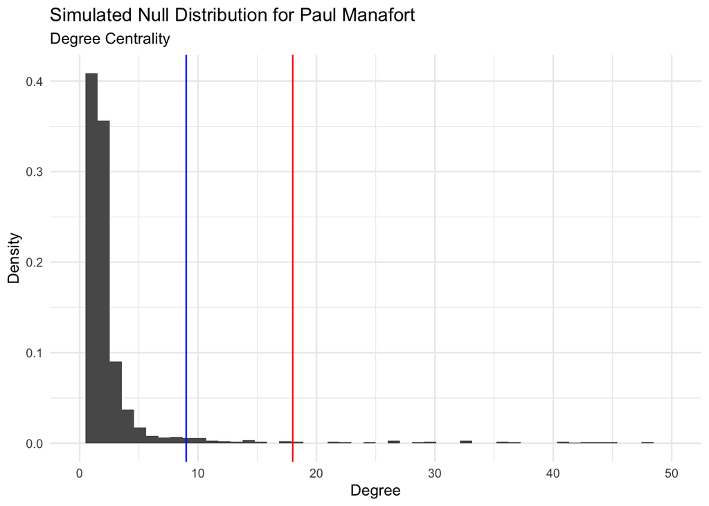

```r
#get original statistics
trump_degree <-  unname(degree(trump_igraph))

#Find bootstrap samples that do no not contain Paul Manafort
n_pm <- which(V(trump_igraph)$name == "PAUL MANAFORT")
n_bootstrap = B*U


Gamma_pm <- c()

for(i in 1:n_bootstrap){
  temp_nodes <- unlist(JaB_trump_degree$Bootstrap_Nodes[[i]])

  #is PM in bootstrap sample i?
  if(!(n_pm %in% temp_nodes )){ #if no....
    #Get the centrality statistics accounting for multiplicity
    #here we consider multiplicity = F, so we only take the unique instances
    if(mult){
      nodes <- temp_nodes
    }else(
      nodes <- unique(temp_nodes)
    )

    #store them in simulated null distribution
    Gamma_pm <- c(Gamma_pm, (trump_degree[nodes]))
  }


}

#get gamma_pm
degree.value <- trump_degree[n_pm] # JaB_trump_degree$Results$Orig_Stat[JaB_trump_degree$Results$Node_Number == n_pm]


#get q^{(pm)}
degree.cutoff <- quantile(Gamma_pm, quants[2]) # = JaB_trump_degree$Results$Upper[JaB_trump_degree$Results$Node_Number == n_pm]


#Plot null distribution
as.data.frame(Gamma_pm) %>%
  ggplot() +
  geom_histogram(aes(x = Gamma_pm, y = ..density..), bins = 50) +
  geom_vline(xintercept = degree.value , col = "red") +
  geom_vline(xintercept = degree.cutoff , col = "blue") +
  theme_minimal() +
  ggtitle("Simulated Null Distribution for Paul Manafort")+
  labs(subtitle = "Degree Centrality") +
  xlab("Degree") +
  ylab("Density") +
  xlim(c(0, 50))
```

#### Closeness Centrality

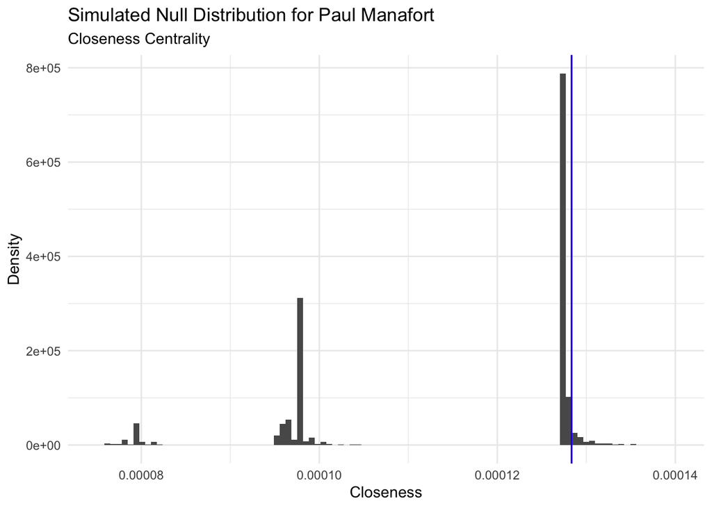

```r
#get original statistics
trump_closeness <-  unname(closeness(trump_igraph))

#Find bootstrap samples that do no not contain Paul Manafort
n_pm <- which(V(trump_igraph)$name == "PAUL MANAFORT")
n_bootstrap = B*U

Gamma_pm <- c()

for(i in 1:n_bootstrap){
  temp_nodes <- unlist(JaB_trump_closeness$Bootstrap_Nodes[[i]])

  #is PM in bootstrap sample i?
  if(!(n_pm %in% temp_nodes )){ #if no....
    #Get the centrality statistics accounting for multiplicity
    #here we consider multiplicity = F, so we only take the unique instances
    if(mult){
      nodes <- temp_nodes
    }else(
      nodes <- unique(temp_nodes)
    )

    #store them in simulated null distribution
    Gamma_pm <- c(Gamma_pm, (trump_closeness[nodes]))
  }


}

#get gamma_pm
closeness.value <- trump_closeness[n_pm] # JaB_trump_closeness$Results$Orig_Stat[JaB_trump_closeness$Results$Node_Number == n_pm]


#get q^{(pm)}
closeness.cutoff <- quantile(Gamma_pm, quants[2]) # = JaB_trump_closeness$Results$Upper[JaB_trump_closeness$Results$Node_Number == n_pm]


#Plot null distribution
as.data.frame(Gamma_pm) %>%
  ggplot() +
  geom_histogram(aes(x = Gamma_pm, y = ..density..), bins = 100) +
  geom_vline(xintercept = closeness.value , col = "red") +
  geom_vline(xintercept = closeness.cutoff , col = "blue") +
  theme_minimal() +
  ggtitle("Simulated Null Distribution for Paul Manafort")+
  labs(subtitle = "Closeness Centrality") +
  xlab("Closeness") +
  ylab("Density") +
  xlim(c(0.000075,0.00014))
```

#### Eigenvector Centrality

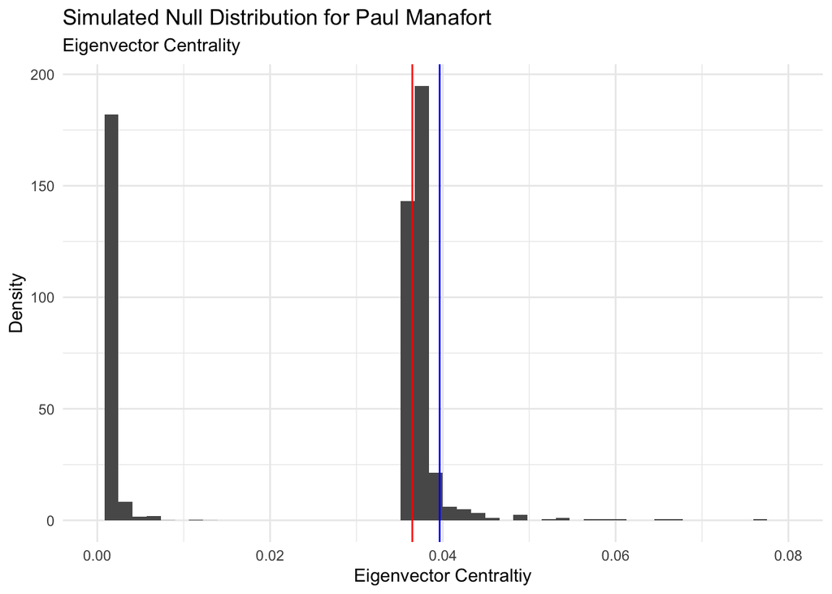

```r
#get original statistics
trump_eigen <-  unname(eigen_centrality(trump_igraph)$vector)

#Find bootstrap samples that do no not contain Paul Manafort
n_pm <- which(V(trump_igraph)$name == "PAUL MANAFORT")
n_bootstrap = B*U

Gamma_pm <- c()

for(i in 1:n_bootstrap){
  temp_nodes <- unlist(JaB_trump_eigen$Bootstrap_Nodes[[i]])

  #is PM in bootstrap sample i?
  if(!(n_pm %in% temp_nodes )){ #if no....
    #Get the centrality statistics accounting for multiplicity
    #here we consider multiplicity = F, so we only take the unique instances
    if(mult){
      nodes <- temp_nodes
    }else(
      nodes <- unique(temp_nodes)
    )

    #store them in simulated null distribution
    Gamma_pm <- c(Gamma_pm, (trump_eigen[nodes]))
  }


}

#get gamma_pm
eigen.value <- trump_eigen[n_pm] # JaB_trump_eigen$Results$Orig_Stat[JaB_trump_eigen$Results$Node_Number == n_pm]


#get q^{(pm)}
eigen.cutoff <- quantile(Gamma_pm, quants[2]) # = JaB_trump_eigen$Results$Upper[JaB_trump_eigen$Results$Node_Number == n_pm]


#Plot null distribution
as.data.frame(Gamma_pm) %>%
  ggplot() +
  geom_histogram(aes(x = Gamma_pm, y = ..density..), bins = 50) +
  geom_vline(xintercept = eigen.value , col = "red") +
  geom_vline(xintercept = eigen.cutoff , col = "blue") +
  theme_minimal() +
  ggtitle("Simulated Null Distribution for Paul Manafort")+
  labs(subtitle = "Eigenvector Centrality")+
  xlab("Eigenvector Centraltiy") +
  ylab("Density") +
  xlim(c(0, 0.08))
```